# Breast Cancer Classification: Model Selection & Discrimination

Biostatistics 735

Author

Alexander McLain

Published

September 15, 2026

```r
# Core
library(tidyverse)
library(rsample)
library(recipes)
library(yardstick)
library(broom)
library(knitr)
library(kableExtra)

# Models
library(glmnet)        # logistic lasso
# MASS functions used via explicit namespace to avoid select() conflicts
# library(MASS)        # we'll call MASS::lda / MASS::qda / MASS::stepAIC directly
```

# 1 Loading in the data

**Data:** Wisconsin Diagnostic Breast Cancer (WDBC)

Each row is a patient. Outcome is diagnosis: Malignant (M) or Benign (B).

There are 30 numeric features computed from a digitized image of a breast mass (10 characteristics × 3 summaries: mean, standard error, “worst”).

```r
# Download from UCI ML repo
  url_data  <- "https://archive.ics.uci.edu/ml/machine-learning-databases/breast-cancer-wisconsin/wdbc.data"
  raw <- read.csv(url_data, header = FALSE)


# According to UCI:
# V1 = ID, V2 = Diagnosis (M/B), V3:V32 = 30 features
names(raw) <- c("ID","Diagnosis",
                "radius_mean","texture_mean","perimeter_mean","area_mean","smoothness_mean",
                "compactness_mean","concavity_mean","concave_points_mean","symmetry_mean","fractal_dimension_mean",
                "radius_se","texture_se","perimeter_se","area_se","smoothness_se",
                "compactness_se","concavity_se","concave_points_se","symmetry_se","fractal_dimension_se",
                "radius_worst","texture_worst","perimeter_worst","area_worst","smoothness_worst",
                "compactness_worst","concavity_worst","concave_points_worst","symmetry_worst","fractal_dimension_worst")

bc <- raw %>%
  as_tibble() %>%
  mutate(Diagnosis = factor(Diagnosis, levels = c("B","M"))) %>%  # B=negative (benign), M=positive (malignant)
  select(-ID)

glimpse(bc)
```

```
Rows: 569
Columns: 31
$ Diagnosis               <fct> M, M, M, M, M, M, M, M, M, M, M, M, M, M, M, M…
$ radius_mean             <dbl> 17.990, 20.570, 19.690, 11.420, 20.290, 12.450…
$ texture_mean            <dbl> 10.38, 17.77, 21.25, 20.38, 14.34, 15.70, 19.9…
$ perimeter_mean          <dbl> 122.80, 132.90, 130.00, 77.58, 135.10, 82.57, …
$ area_mean               <dbl> 1001.0, 1326.0, 1203.0, 386.1, 1297.0, 477.1, …
$ smoothness_mean         <dbl> 0.11840, 0.08474, 0.10960, 0.14250, 0.10030, 0…
$ compactness_mean        <dbl> 0.27760, 0.07864, 0.15990, 0.28390, 0.13280, 0…
$ concavity_mean          <dbl> 0.30010, 0.08690, 0.19740, 0.24140, 0.19800, 0…
$ concave_points_mean     <dbl> 0.14710, 0.07017, 0.12790, 0.10520, 0.10430, 0…
$ symmetry_mean           <dbl> 0.2419, 0.1812, 0.2069, 0.2597, 0.1809, 0.2087…
$ fractal_dimension_mean  <dbl> 0.07871, 0.05667, 0.05999, 0.09744, 0.05883, 0…
$ radius_se               <dbl> 1.0950, 0.5435, 0.7456, 0.4956, 0.7572, 0.3345…
$ texture_se              <dbl> 0.9053, 0.7339, 0.7869, 1.1560, 0.7813, 0.8902…
```

[output cut: 18 more lines]

```r
summary(bc$Diagnosis)
```

```
  B   M
357 212
```

We’ll create a train/test split once, then do model selection and evaluation within the training set (for AIC/BIC and CV). The test set is reserved for a final sanity check (optional).

```r
set.seed(42)
split <- initial_split(bc, prop = 0.8, strata = Diagnosis)
train <- training(split)
test  <- testing(split)

nrow(train); nrow(test)
```

```
[1] 454
```

```
[1] 115
```

**Preprocessing Recipe**

Before commensing with the CV, we’re going to create some functions to help us scale/center predictors and keep the outcome as a factor. This avoids leakage by **fitting the recipe inside resamples** when used with rsample.

The `recipe()` function is a description of the steps to be applied to a data set in order to prepare it for data analysis.

```r
rec_base <- recipe(Diagnosis ~ ., data = train) %>%
  step_zv(all_predictors()) %>%
  step_normalize(all_predictors())
prep_base <- prep(rec_base)         # for direct train fit (non-CV steps)
train_ready <- bake(prep_base, train)
test_ready  <- bake(prep_base, test)
```

Here, we’re telling `R` that we are doing two steps:

- `step_zv()` creates a *specification* of a recipe step that will remove variables that contain only a single value.
- `step_normalize()` creates a *specification* of a recipe step that will normalize numeric data to have a standard deviation of one and a mean of zero.
- `prep()` estimates the required parameters from a training set that can be later applied to other data sets.
- `bake()` will apply the computations to new data.

⸻

# 2 Logistic Regression with AIC and BIC

We fit a full logistic regression on all 30 predictors, then run stepwise selection:

• AIC via MASS::stepAIC (default),

• BIC via MASS::stepAIC(…, k = log(n)).

```r
full_glm <- glm(Diagnosis ~ ., data = train_ready, family = binomial())
null_glm <- glm(Diagnosis ~ 1, data = train_ready, family = binomial())

summary(full_glm)$coef |> kable(digits = 3)
```

|  | Estimate | Std. Error | z value | Pr(>\|z\|) |
| --- | --- | --- | --- | --- |
| (Intercept) | 67.714 | 22055.94 | 0.003 | 0.998 |
| radius_mean | -5660.751 | 696342.61 | -0.008 | 0.994 |
| texture_mean | 202.241 | 32185.00 | 0.006 | 0.995 |
| perimeter_mean | 1213.332 | 416806.69 | 0.003 | 0.998 |
| area_mean | 3918.655 | 178598.91 | 0.022 | 0.982 |
| smoothness_mean | 73.781 | 12060.92 | 0.006 | 0.995 |
| compactness_mean | -954.334 | 64327.70 | -0.015 | 0.988 |
| concavity_mean | -99.537 | 72935.85 | -0.001 | 0.999 |
| concave_points_mean | 998.568 | 78814.70 | 0.013 | 0.990 |
| symmetry_mean | -49.558 | 11232.99 | -0.004 | 0.996 |
| fractal_dimension_mean | 222.074 | 15017.95 | 0.015 | 0.988 |
| radius_se | 320.766 | 120977.10 | 0.003 | 0.998 |
| texture_se | -12.149 | 27804.72 | 0.000 | 1.000 |
| perimeter_se | -378.510 | 126474.19 | -0.003 | 0.998 |
| area_se | 420.796 | 199280.83 | 0.002 | 0.998 |
| smoothness_se | -101.566 | 21567.42 | -0.005 | 0.996 |
| compactness_se | 243.466 | 47276.11 | 0.005 | 0.996 |
| concavity_se | -34.920 | 51534.84 | -0.001 | 0.999 |
| concave_points_se | 325.908 | 71412.02 | 0.005 | 0.996 |
| symmetry_se | -133.701 | 40707.48 | -0.003 | 0.997 |
| fractal_dimension_se | -395.866 | 67585.39 | -0.006 | 0.995 |
| radius_worst | 4401.821 | 228633.45 | 0.019 | 0.985 |
| texture_worst | 55.813 | 33654.28 | 0.002 | 0.999 |
| perimeter_worst | 211.358 | 202784.68 | 0.001 | 0.999 |
| area_worst | -3699.577 | 220615.93 | -0.017 | 0.987 |
| smoothness_worst | 12.869 | 21316.84 | 0.001 | 1.000 |
| compactness_worst | -34.063 | 81183.49 | 0.000 | 1.000 |
| concavity_worst | 362.026 | 86827.91 | 0.004 | 0.997 |
| concave_points_worst | -36.007 | 87882.19 | 0.000 | 1.000 |
| symmetry_worst | 195.960 | 22590.26 | 0.009 | 0.993 |
| fractal_dimension_worst | 82.055 | 74593.96 | 0.001 | 0.999 |

```r
# AIC-based backwards (backwards starting at full model)
aic_fit <- MASS::stepAIC(full_glm, direction = "backward", trace = FALSE)

# BIC-based backwards (penalty k = log(n))
n_train <- nrow(train_ready)
#BIC gives the same model as AIC when backwards is used
#bic_fit <- MASS::stepAIC(full_glm, direction = "backward",
#                         k = log(n_train), trace = FALSE)

# BIC-based stepwise (penalty k = log(n))
bic_fit <- MASS::stepAIC(null_glm,
                         direction = "both",
                         k = log(n_train),
                         scope=list(lower=null_glm,
                                    upper=full_glm),
                         trace = FALSE)

# Summaries
tibble(
  AIC_parms = length(coef(aic_fit)),
  BIC_parms = length(coef(bic_fit)))
```

```
# A tibble: 1 × 2
  AIC_parms BIC_parms
      <int>     <int>
1        20         7
```

```r
formula(aic_fit)
```

```
Diagnosis ~ radius_mean + texture_mean + area_mean + smoothness_mean +
    compactness_mean + concave_points_mean + fractal_dimension_mean +
    radius_se + perimeter_se + smoothness_se + compactness_se +
    concave_points_se + symmetry_se + fractal_dimension_se +
    radius_worst + area_worst + concavity_worst + symmetry_worst +
    fractal_dimension_worst
```

```r
formula(bic_fit)
```

```
Diagnosis ~ perimeter_worst + smoothness_worst + texture_worst +
    radius_se + concave_points_worst + compactness_mean
```

## 2.1 Estimating the ROC curve and AUC from the full model.

```r
# Predicted probabilities for the Malignant class ("M")
p_train_full <- predict(full_glm, type = "response")
p_test_full  <- predict(full_glm, newdata = test_ready, type = "response")


# 1) ROC curves (training & test)
ROC_data_train <- train_ready %>%
  mutate(estimate = p_train_full)

# We use event_level = "second" because the probabilities predict "M"
levels(ROC_data_train$Diagnosis)
```

```
[1] "B" "M"
```

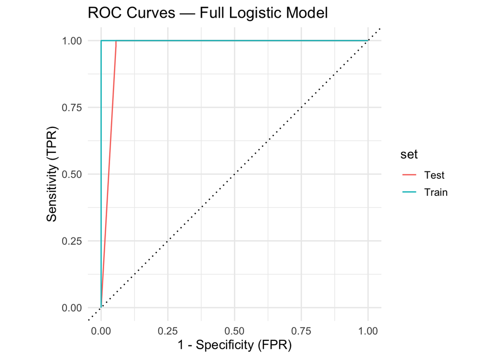

```r
roc_train <- yardstick::roc_curve(data = ROC_data_train,
                                  Diagnosis, estimate,
                                  event_level = "second") %>%
  mutate(set = "Train")

ROC_data_test <- test_ready  %>%
  mutate(estimate = p_test_full)
roc_test  <- yardstick::roc_curve(data = ROC_data_test,
                                  Diagnosis, estimate,
                                  event_level = "second") %>%
  mutate(set = "Test")

bind_rows(roc_train, roc_test) %>%
  ggplot(aes(x = 1 - specificity, y = sensitivity, color = set)) +
  geom_path() +
  geom_abline(slope = 1, intercept = 0, linetype = 3) +
  coord_equal() +
  labs(title = "ROC Curves — Full Logistic Model",
       x = "1 - Specificity (FPR)", y = "Sensitivity (TPR)") +
  theme_minimal(base_size = 13)
```

AUC on training & test for reference.

```r
tibble(
  set = c("Train", "Test"),
  AUC = c(
    roc_auc_vec(train_ready$Diagnosis, p_train_full, event_level = "second"),
    roc_auc_vec(test_ready$Diagnosis,  p_test_full,  event_level = "second")
  )
) |> kable(digits = 3)
```

| set | AUC |
| --- | --- |
| Train | 1.000 |
| Test | 0.972 |

AUC on test from the AIC and BIC models.

```r
pred_aic <- predict(aic_fit, newdata = test_ready, type = "response")
pred_bic <- predict(bic_fit, newdata = test_ready, type = "response")
tibble(
  model = c("AIC","BIC"),
  AUC   = c(roc_auc_vec(test_ready$Diagnosis, pred_aic, event_level = "second"),
            roc_auc_vec(test_ready$Diagnosis, pred_bic, event_level = "second"))
) %>% kable(digits = 3)
```

| model | AUC |
| --- | --- |
| AIC | 0.972 |
| BIC | 0.996 |

## 2.2 Youden’s Index

Youden’s Index (J) is a single number that summarizes how well a classifier balances **sensitivity** and **specificity**. It is defined as

[ J = Sensitivity + Specificity - 1 ]

The value of J ranges from 0 (no better than chance) to 1 (perfect classification). In practice, we can compute J at every possible classification threshold and then choose the threshold that maximizes J. This threshold gives the “best balance” between correctly identifying positives and negatives, and is often used when there is no clear reason to favor sensitivity over specificity (or vice versa).

### 2.2.1 Estimating Youden’s J from the full model.

The following function will tune the threshold and find Youden’s J on the training portion data.

```r
# Grid-search threshold to maximize Youden's J on TRAINING data within a fold
tune_threshold_j <- function(truth, prob, grid = seq(0.001, 0.999, by = 0.001)) {
  # truth: factor with levels c("B","M"), "M" is the event
  # prob:  numeric vector of P(event="M")
  stopifnot(is.factor(truth), length(levels(truth)) == 2)
  best_thr <- 0.5
  best_j   <- -Inf
  for (t in grid) {
    cls <- factor(ifelse(prob >= t, levels(truth)[2], levels(truth)[1]),
                  levels = levels(truth))
    se  <- sens_vec(truth, cls, event_level = "second")
    sp  <- spec_vec(truth, cls, event_level = "second")
    j   <- as.numeric(se + sp - 1)
    if (!is.na(j) && j > best_j) {
      best_j   <- j
      best_thr <- t
    }
  }
  best_thr
}
```

```r
# 3) Choose threshold by Youden's J on TRAINING data
thr_youden <- tune_threshold_j(truth = train_ready$Diagnosis, prob = p_train_full)
thr_youden
```

```
[1] 0.001
```

```r
# 4) Metrics at the Youden-tuned threshold (Train & Test)
cls_train <- factor(ifelse(p_train_full >= thr_youden, "M", "B"),
                    levels = levels(train_ready$Diagnosis))
cls_test  <- factor(ifelse(p_test_full  >= thr_youden, "M", "B"),
                    levels = levels(test_ready$Diagnosis))

metrics_tbl <- tribble(~set, ~AUC, ~Sensitivity, ~Specificity, ~PPV, ~NPV,
  "Train",
  roc_auc_vec(train_ready$Diagnosis, p_train_full, event_level = "second"),
  sens_vec(train_ready$Diagnosis, cls_train, event_level = "second"),
  spec_vec(train_ready$Diagnosis, cls_train, event_level = "second"),
  ppv_vec (train_ready$Diagnosis, cls_train, event_level = "second"),
  npv_vec (train_ready$Diagnosis, cls_train, event_level = "second"),
  "Test",
  roc_auc_vec(test_ready$Diagnosis,  p_test_full,  event_level = "second"),
  sens_vec(test_ready$Diagnosis,  cls_test,  event_level = "second"),
  spec_vec(test_ready$Diagnosis,  cls_test,  event_level = "second"),
  ppv_vec (test_ready$Diagnosis,  cls_test,  event_level = "second"),
  npv_vec (test_ready$Diagnosis,  cls_test,  event_level = "second")
)

metrics_tbl %>% kable(digits = 3,
                      caption = paste0("Full Model Performance at Youden's Threshold (t = ", round(thr_youden, 3), ")"))
```

Full Model Performance at Youden’s Threshold (t = 0.001)

| set | AUC | Sensitivity | Specificity | PPV | NPV |
| --- | --- | --- | --- | --- | --- |
| Train | 1.000 | 1.000 | 1.000 | 1.000 | 1.000 |
| Test | 0.972 | 0.977 | 0.944 | 0.913 | 0.986 |

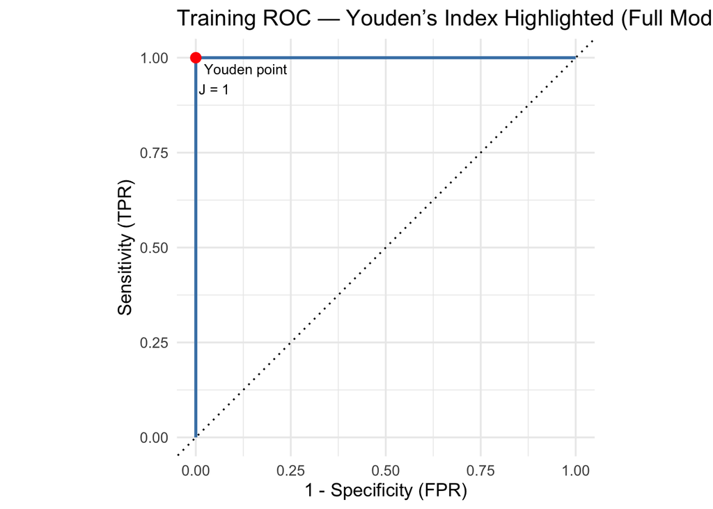

```r
# 5) (Optional) Visualize the training ROC with the Youden point highlighted
#    Compute J across thresholds from the training ROC object
roc_train_with_j <- roc_train %>%
  mutate(J = sensitivity + specificity - 1)

idx_best <- which.max(roc_train_with_j$J)
pt <- roc_train_with_j[idx_best, ]

ggplot(roc_train_with_j, aes(x = 1 - specificity, y = sensitivity)) +
  geom_path(color = "steelblue", linewidth = 1) +
  geom_abline(slope = 1, intercept = 0, linetype = 3) +
  geom_point(data = pt, color = "red", size = 3) +
  annotate("text",
           x = 1 - pt$specificity, y = pt$sensitivity,
           label = paste0("Youden point\nJ = ", round(pt$J, 3)),
           hjust = -0.1, vjust = 1.2, size = 3.5) +
  coord_equal() +
  labs(title = "Training ROC — Youden’s Index Highlighted (Full Model)",
       x = "1 - Specificity (FPR)", y = "Sensitivity (TPR)") +
  theme_minimal(base_size = 13)
```

⸻

# 3 CV Model Selection using AUC, Specificity, and NPV

We’ll compare three candidates on the training data using 10-fold stratified CV:

• Full logistic model (all 30 predictors),

• AIC-selected model,

• BIC-selected model.

For specificity and NPV we’ll use a fixed threshold 0.5 for probabilities for now.

```r
set.seed(735794)
folds <- vfold_cv(train, v = 10, strata = Diagnosis)

# helper: fit a recipe + model in one fold, then compute metrics on assessment
evaluate_glm_cv <- function(formula_obj, folds, base_recipe, threshold = 0.5) {
  map_dfr(seq_len(nrow(folds)), function(i){
    sp  <- folds$splits[[i]]
    tr  <- analysis(sp)
    va  <- assessment(sp)

    # fold-specific preprocessing to prevent leakage
    rec <- prep(base_recipe, training = tr)
    trx <- bake(rec, tr)
    vax <- bake(rec, va)

    fit <- glm(formula_obj, data = trx, family = binomial())
    p   <- predict(fit, newdata = vax, type = "response")
    cls <- factor(ifelse(p >= threshold, "M", "B"), levels = levels(vax$Diagnosis))

    tibble(
      fold = i,
      auc  = roc_auc_vec(vax$Diagnosis, p,   event_level = "second"),
      spec = spec_vec(vax$Diagnosis, cls,    event_level = "second"),
      npv  = npv_vec(vax$Diagnosis,  cls,    event_level = "second")
    )
  }) %>%
    summarise(across(c(auc,spec,npv), list(mean = mean, sd = sd)))
}

# Build candidate formulas
form_full <- as.formula(Diagnosis ~ .)
form_aic  <- formula(aic_fit)
form_bic  <- formula(bic_fit)

cv_full <- evaluate_glm_cv(form_full, folds, rec_base)
cv_aic  <- evaluate_glm_cv(form_aic,  folds, rec_base)
cv_bic  <- evaluate_glm_cv(form_bic,  folds, rec_base)

bind_rows(
  mutate(cv_full, model = "Full"),
  mutate(cv_aic,  model = "AIC"),
  mutate(cv_bic,  model = "BIC")
) %>%
  relocate(model) %>%
  kable(digits = 3, caption = "10-fold CV metrics (threshold = 0.5)") %>%
  kable_styling(full_width = FALSE)
```

10-fold CV metrics (threshold = 0.5)

| model | auc_mean | auc_sd | spec_mean | spec_sd | npv_mean | npv_sd |
| --- | --- | --- | --- | --- | --- | --- |
| Full | 0.942 | 0.035 | 0.930 | 0.032 | 0.957 | 0.032 |
| AIC | 0.959 | 0.038 | 0.961 | 0.048 | 0.969 | 0.037 |
| BIC | 0.993 | 0.011 | 0.982 | 0.045 | 0.973 | 0.038 |

**Selection:** pick the model that best aligns with your goal (e.g., highest AUC overall; or, for screening, prioritize high NPV/sensitivity).

The AUC, NPV, sensitivity, etc. from the best model are biased for two reasons: (i) we chose the model based on these values, (ii) we used all the training data to get the AIC/BIC models.

To get unbiased error estimation, we’ll evaluate the chosen model on the held-out test set:

```r
# pick by AUC mean (example)
cv_table <- bind_rows(
  mutate(cv_full, model = "Full"),
  mutate(cv_aic,  model = "AIC"),
  mutate(cv_bic,  model = "BIC")
) %>% mutate(auc_mean = auc_mean)

(best_model <- cv_table$model[which.max(cv_table$auc_mean)])
```

```
[1] "BIC"
```

```r
best_form  <- list(Full = form_full, AIC = form_aic, BIC = form_bic)[[best_model]]

# final refit on entire training (with preprocessing from earlier)
final_glm <- glm(best_form, data = train_ready, family = binomial())
p_test    <- predict(final_glm, newdata = test_ready, type = "response")
cls_test  <- factor(ifelse(p_test >= 0.5, "M","B"), levels = levels(test_ready$Diagnosis))

tibble(
  set  = "Test",
  AUC  = roc_auc_vec(test_ready$Diagnosis, p_test,  event_level = "second"),
  Spec = spec_vec(test_ready$Diagnosis,    cls_test, event_level = "second"),
  NPV  = npv_vec(test_ready$Diagnosis,     cls_test, event_level = "second")
) %>% kable(digits = 3)
```

| set | AUC | Spec | NPV |
| --- | --- | --- | --- |
| Test | 0.996 | 0.972 | 0.972 |

⸻

## 3.1 CV with tuned threshold (Youden J inside each fold)

What we do below is similar to above, but it answers a different questions. Which is the best model (full/AIC/BIC) when each have their thresholds for positive/negative tuned using Youden’s J.

```r
# Evaluate a GLM with fold-wise preprocessing and THRESHOLD TUNING by Youden's J
evaluate_glm_cv_tuned <- function(formula_obj, folds, base_recipe) {
  map_dfr(seq_len(nrow(folds)), function(i){
    sp  <- folds$splits[[i]]
    tr  <- analysis(sp)
    va  <- assessment(sp)

    # fold-specific preprocessing (prevents leakage)
    rec <- prep(base_recipe, training = tr)
    trx <- bake(rec, tr)
    vax <- bake(rec, va)

    # fit on training portion
    fit <- glm(formula_obj, data = trx, family = binomial())

    # --- Threshold tuning on TRAINING portion (resubstitution) ---
    p_tr   <- predict(fit, newdata = trx, type = "response")
    thr_j  <- tune_threshold_j(truth = trx$Diagnosis, prob = p_tr)

    # --- Evaluate on VALIDATION portion using tuned threshold ---
    p_va   <- predict(fit, newdata = vax, type = "response")
    cls_va <- factor(ifelse(p_va >= thr_j, "M", "B"), levels = levels(vax$Diagnosis))

    tibble(
      fold = i,
      thr  = thr_j,
      auc  = roc_auc_vec(vax$Diagnosis, p_va,   event_level = "second"),
      spec = spec_vec(vax$Diagnosis,    cls_va, event_level = "second"),
      npv  = npv_vec(vax$Diagnosis,     cls_va, event_level = "second")
    )
  }) %>%
    summarise(
      thr_mean = mean(thr),
      thr_sd   = sd(thr),
      across(c(auc, spec, npv), list(mean = mean, sd = sd))
    )
}
```

Run tuned-threshold CV for your three candidate models

```r
set.seed(735794)
folds <- vfold_cv(train, v = 10, strata = Diagnosis)

cv_full_tuned <- evaluate_glm_cv_tuned(form_full, folds, rec_base)
cv_aic_tuned  <- evaluate_glm_cv_tuned(form_aic,  folds, rec_base)
cv_bic_tuned  <- evaluate_glm_cv_tuned(form_bic,  folds, rec_base)

bind_rows(
  mutate(cv_full_tuned, model = "Full"),
  mutate(cv_aic_tuned,  model = "AIC"),
  mutate(cv_bic_tuned,  model = "BIC")
) %>%
  relocate(model) %>%
  kable(digits = 3,
        caption = "10-fold CV with fold-wise threshold tuning (Youden's J on training portion)")
```

10-fold CV with fold-wise threshold tuning (Youden’s J on training portion)

| model | thr_mean | thr_sd | auc_mean | auc_sd | spec_mean | spec_sd | npv_mean | npv_sd |
| --- | --- | --- | --- | --- | --- | --- | --- | --- |
| Full | 0.001 | 0.000 | 0.942 | 0.035 | 0.930 | 0.032 | 0.961 | 0.031 |
| AIC | 0.001 | 0.000 | 0.959 | 0.038 | 0.961 | 0.048 | 0.969 | 0.037 |
| BIC | 0.411 | 0.082 | 0.993 | 0.011 | 0.975 | 0.056 | 0.969 | 0.037 |

⸻

Notes to include beneath the table (optional)

• What changed? Instead of using a fixed 0.5 threshold, each fold now learns its own threshold from the training portion by maximizing Youden’s J (sensitivity + specificity − 1).

• Why do this? If class prevalence or costs are asymmetric, tuning the threshold can substantially improve specificity or NPV (or sensitivity) compared with a fixed 0.5.

• **Caveat:** This is still within-fold tuning (based on resubstitution on the training portion), which is acceptable for model selection but will give biased estimates of the error. If you want unbiased estimates of performance, combine this with nested CV or keep a held-out test set for the final report.

# 4 Logistic Lasso (glmnet)

We fit a penalized logistic regression (lasso) with internal CV to choose ($\lambda$). Then evaluate on the test set.

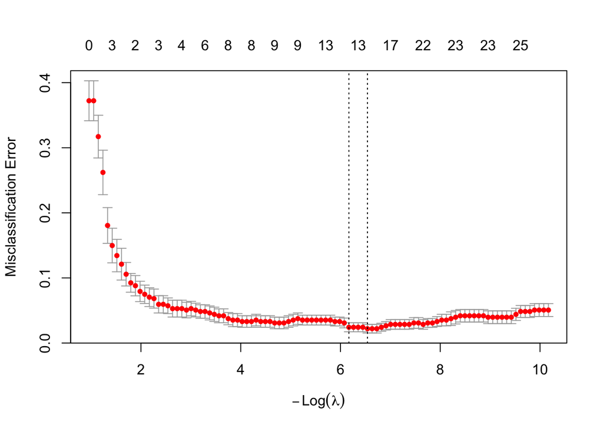

```r
# Rebuild design matrices from the preprocessed data
x_tr <- model.matrix(Diagnosis ~ . - 1, data = train_ready)
y_tr <- train_ready$Diagnosis

x_te <- model.matrix(Diagnosis ~ . - 1, data = test_ready)
y_te <- test_ready$Diagnosis

set.seed(202)
cv_lasso <- cv.glmnet(x_tr, y_tr, alpha = 1, family = "binomial",
                      nfolds = 10, type.measure = "class")
plot(cv_lasso)
```

```r
lam_min  <- cv_lasso$lambda.min
lam_1se  <- cv_lasso$lambda.1se

fit_min <- glmnet(x_tr, y_tr, alpha = 1, family = "binomial", lambda = lam_min)
fit_1se <- glmnet(x_tr, y_tr, alpha = 1, family = "binomial", lambda = lam_1se)


tibble(
  Variable = rownames(coef(fit_min))[-1],
  coef_full = coef(full_glm)[-1],
  coef_min = coef(fit_min)[-1],
  coef_1se = coef(fit_1se)[-1],
) %>% kable(digits = 3, caption = "Coefficient estimates for Logistic Lasso (note: all X and standardized).")
```

Coefficient estimates for Logistic Lasso (note: all X and standardized).

| Variable | coef_full | coef_min | coef_1se |
| --- | --- | --- | --- |
| radius_mean | -5660.751 | 0.000 | 0.000 |
| texture_mean | 202.241 | 0.000 | 0.000 |
| perimeter_mean | 1213.332 | 0.000 | 0.000 |
| area_mean | 3918.655 | 0.000 | 0.000 |
| smoothness_mean | 73.781 | 0.000 | 0.000 |
| compactness_mean | -954.334 | -0.709 | -0.305 |
| concavity_mean | -99.537 | 0.000 | 0.000 |
| concave_points_mean | 998.568 | 1.812 | 1.323 |
| symmetry_mean | -49.558 | -0.032 | 0.000 |
| fractal_dimension_mean | 222.074 | 0.000 | -0.020 |
| radius_se | 320.766 | 3.258 | 2.801 |
| texture_se | -12.149 | -0.436 | -0.277 |
| perimeter_se | -378.510 | 0.000 | 0.000 |
| area_se | 420.796 | 0.000 | 0.000 |
| smoothness_se | -101.566 | 0.291 | 0.250 |
| compactness_se | 243.466 | -0.545 | -0.463 |
| concavity_se | -34.920 | 0.000 | 0.000 |
| concave_points_se | 325.908 | 0.000 | 0.000 |
| symmetry_se | -133.701 | 0.000 | 0.000 |
| fractal_dimension_se | -395.866 | -0.502 | -0.453 |
| radius_worst | 4401.821 | 3.544 | 3.437 |
| texture_worst | 55.813 | 1.724 | 1.510 |
| perimeter_worst | 211.358 | 0.000 | 0.000 |
| area_worst | -3699.577 | 0.000 | 0.000 |
| smoothness_worst | 12.869 | 0.662 | 0.584 |
| compactness_worst | -34.063 | 0.000 | 0.000 |
| concavity_worst | 362.026 | 1.495 | 1.216 |
| concave_points_worst | -36.007 | 1.434 | 1.370 |
| symmetry_worst | 195.960 | 0.417 | 0.335 |
| fractal_dimension_worst | 82.055 | 0.000 | 0.000 |

```r
p_min <- predict(fit_min, newx = x_te, type = "response")[,1]
p_1se <- predict(fit_1se, newx = x_te, type = "response")[,1]

cls_min <- factor(ifelse(p_min >= 0.5, "M","B"), levels = levels(y_te))
cls_1se <- factor(ifelse(p_1se >= 0.5, "M","B"), levels = levels(y_te))


tibble(
  model = c("Lasso (min)","Lasso (1SE)"),
  AUC   = c(roc_auc_vec(y_te, p_min, event_level = "second"),
            roc_auc_vec(y_te, p_1se, event_level = "second")),
  Spec  = c(spec_vec(y_te, cls_min, event_level = "second"),
            spec_vec(y_te, cls_1se, event_level = "second")),
  NPV   = c(npv_vec(y_te, cls_min, event_level = "second"),
            npv_vec(y_te, cls_1se, event_level = "second"))
) %>% kable(digits = 3, caption = "Test-set performance: Logistic Lasso")
```

Test-set performance: Logistic Lasso

| model | AUC | Spec | NPV |
| --- | --- | --- | --- |
| Lasso (min) | 0.999 | 0.972 | 1.000 |
| Lasso (1SE) | 0.999 | 0.986 | 0.986 |

Inspect sparsity:

```r
nnz <- function(m) sum(as.numeric(m)!=0)
tibble(
  Model = c("Lasso (min)","Lasso (1SE)"),
  Nonzero = c(nnz(coef(fit_min)), nnz(coef(fit_1se)))
) %>% kable()
```

| Model | Nonzero |
| --- | --- |
| Lasso (min) | 15 |
| Lasso (1SE) | 15 |

# 5 LDA and QDA

We’ll fit LDA and QDA (after standardizing predictors). QDA can have singularity issues when classes are small; standardization and all-numeric predictors help.

```r
# Train LDA/QDA on preprocessed training data
lda_fit <- MASS::lda(Diagnosis ~ ., data = train_ready)
qda_fit <- MASS::qda(Diagnosis ~ ., data = train_ready)

# Predict on test set
pred_lda <- predict(lda_fit, newdata = test_ready)
pred_qda <- predict(qda_fit, newdata = test_ready)

head(pred_lda$posterior)
```

```
             B         M
1 1.726921e-06 0.9999983
2 1.760762e-03 0.9982392
3 4.606236e-02 0.9539376
4 8.930592e-04 0.9991069
5 5.923473e-05 0.9999408
6 3.339797e-04 0.9996660
```

```r
head(pred_lda$class)
```

```
[1] M M M M M M
Levels: B M
```

```r
# yardstick expects class probs for AUC; LDA/QDA return posteriors
p_lda <- pred_lda$posterior[, "M"]
p_qda <- pred_qda$posterior[, "M"]

cls_lda <- factor(pred_lda$class, levels = levels(test_ready$Diagnosis))
cls_qda <- factor(pred_qda$class, levels = levels(test_ready$Diagnosis))

tibble(
  model = c("LDA","QDA"),
  AUC   = c(roc_auc_vec(test_ready$Diagnosis, p_lda, event_level = "second"),
            roc_auc_vec(test_ready$Diagnosis, p_qda, event_level = "second")),
  Spec  = c(spec_vec(test_ready$Diagnosis, cls_lda, event_level = "second"),
            spec_vec(test_ready$Diagnosis, cls_qda, event_level = "second")),
  NPV   = c(npv_vec(test_ready$Diagnosis,  cls_lda, event_level = "second"),
            npv_vec(test_ready$Diagnosis,  cls_qda, event_level = "second"))
) %>% kable(digits = 3, caption = "Test-set performance: LDA and QDA")
```

Test-set performance: LDA and QDA

| model | AUC | Spec | NPV |
| --- | --- | --- | --- |
| LDA | 0.997 | 0.986 | 0.973 |
| QDA | 0.987 | 0.958 | 1.000 |

```r
# General CV evaluation for LDA or QDA with fold-wise preprocessing and cutoff tuning
evaluate_discriminant_cv <- function(method = c("lda","qda"),
                                     folds, base_recipe) {
  method <- match.arg(method)

  map_dfr(seq_len(nrow(folds)), function(i){
    sp  <- folds$splits[[i]]
    tr  <- analysis(sp)
    va  <- assessment(sp)

    # Fold-specific preprocessing to avoid leakage
    rec <- prep(base_recipe, training = tr)
    trx <- bake(rec, tr)
    vax <- bake(rec, va)

    # Fit LDA/QDA on TRAIN
    fit <- switch(method,
                  lda = MASS::lda(Diagnosis ~ ., data = trx),
                  qda = MASS::qda(Diagnosis ~ ., data = trx))

    # Posterior probs for the Malignant class ("M")
    p_tr <- predict(fit, newdata = trx)$posterior[, "M"]
    p_va <- predict(fit, newdata = vax)$posterior[, "M"]

    # Tune threshold on TRAIN by Youden's J
    thr  <- tune_threshold_j(truth = trx$Diagnosis, prob = p_tr)

    # Evaluate on VALIDATION at tuned threshold
    cls_va <- factor(ifelse(p_va >= thr, "M", "B"), levels = levels(vax$Diagnosis))

    tibble(
      fold = i,
      thr  = thr,
      auc  = roc_auc_vec(vax$Diagnosis, p_va,   event_level = "second"),
      spec = spec_vec(vax$Diagnosis,    cls_va, event_level = "second"),
      npv  = npv_vec(vax$Diagnosis,     cls_va, event_level = "second")
    )
  }) %>%
    summarise(
      thr_mean = mean(thr), thr_sd = sd(thr),
      auc_mean = mean(auc), auc_sd = sd(auc),
      spec_mean = mean(spec), spec_sd = sd(spec),
      npv_mean  = mean(npv),  npv_sd  = sd(npv)
    )
}

set.seed(735794)
folds <- vfold_cv(train, v = 10, strata = Diagnosis)

cv_lda <- evaluate_discriminant_cv("lda", folds, rec_base)
cv_qda <- evaluate_discriminant_cv("qda", folds, rec_base)

bind_rows(
  mutate(cv_lda, model = "LDA"),
  mutate(cv_qda, model = "QDA")
) %>%
  relocate(model) %>%
  kable(digits = 3,
        caption = "10-fold CV with fold-wise Youden tuning: LDA vs QDA") %>%
  kable_styling(full_width = FALSE)
```

10-fold CV with fold-wise Youden tuning: LDA vs QDA

| model | thr_mean | thr_sd | auc_mean | auc_sd | spec_mean | spec_sd | npv_mean | npv_sd |
| --- | --- | --- | --- | --- | --- | --- | --- | --- |
| LDA | 0.094 | 0.018 | 0.986 | 0.019 | 0.972 | 0.028 | 0.977 | 0.034 |
| QDA | 0.182 | 0.271 | 0.984 | 0.023 | 0.944 | 0.045 | 0.965 | 0.036 |

⸻

# 6 Wrap-Up

• AIC/BIC give quick, interpretable logistic models;

• CV + AUC/Spec/NPV lets us pick models aligned with clinical goals (e.g., high NPV for screening);

• Lasso adds regularization and automatic feature selection;

• LDA/QDA provide classical discriminant approaches—often surprisingly competitive after proper standardization.